# Title:“Exploratory Data Analysis - Sports”

#### GRIP-The Spark Foundation

#### Data Science and Business Analytics

#### Task:Perform ‘Exploratory Data Analysis’ on dataset ‘Indian Premier League’

#### Problem statement:

**1. Most successful teams based on no:**

- Most of wins,
- The team wins by batting first,
- Win by largest margin of runs,
- Narrowest win margin (by 1 run),
- In most matches, the team wins by bowling first,
- Teams with most win by wickets margin(TOP 10),
- Narrowest win margins (by wickets) and
- Teams scoring highest runs in a match.

**2. Most successful players based On:**

- Batsman Record,
- Bowler Record,
- Batsman vs Bowler Record.

**3. Factors affecting the result of matches such as winning toss:**

#### **The libraries are loaded**

```r
library(tidyverse)
library(DT)
```

#### **Import data**

```r
deliveries= read.csv("deliveries.csv", stringsAsFactors = F)
matches= read.csv("matches.csv", stringsAsFactors = F)
```

### **1. Most successful teams based on no:**

#### **Teams with most wins(TOP 10)**

```r
most_wins= matches %>%
  group_by(winner) %>%
  dplyr::summarise(Total_wins=n()) %>%
  top_n(10) %>%
  arrange(desc(Total_wins))
datatable(most_wins)
```

|  | winner | Total_wins |
| --- | --- | --- |
| 1 | Mumbai Indians | 109 |
| 2 | Chennai Super Kings | 100 |
| 3 | Kolkata Knight Riders | 92 |
| 4 | Royal Challengers Bangalore | 84 |
| 5 | Kings XI Punjab | 82 |
| 6 | Rajasthan Royals | 75 |
| 7 | Delhi Daredevils | 67 |
| 8 | Sunrisers Hyderabad | 58 |
| 9 | Deccan Chargers | 29 |
| 10 | Gujarat Lions | 13 |

#### **Plot a corresponding bar graph**

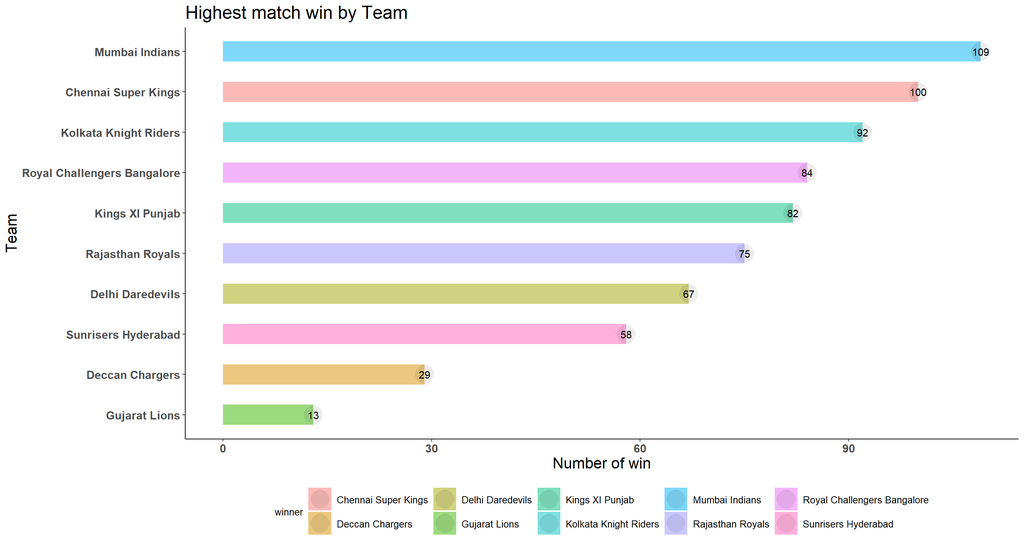

```r
ggplot(most_wins,aes(reorder(winner,Total_wins),Total_wins,fill=winner,label=Total_wins))+
  geom_bar(stat = "identity", width = 0.5, alpha = 0.5)+
  geom_point(size=9, color="black",alpha=0.07)+
  scale_x_discrete(labels = most_wins[order(most_wins$Total_wins),]$winner) +
  theme_classic()+
  geom_text(aes(winner,Total_wins,label =Total_wins))+
  labs(x = "Team", y = "Number of win", title = "Highest match win by Team", size=0.03)+
  coord_flip()+
  theme(axis.text = element_text(size = 12, face = "bold"), title  =  element_text(size = 16,))+
  theme(legend.title = element_text(size=10),legend.text = element_text(size=10),legend.position="bottom")
```

**From the plot we can conclude that Mumbai Indians is the most successful team in terms of number of wins**

#### **In most matches, the team wins by batting first. (TOP 10)**

```r
most_win_by_runs=matches %>%
  filter(win_by_runs!=0)%>%
  group_by(winner) %>%
  dplyr::summarise(Total_win=n()) %>%
  arrange(desc(Total_win))%>%
  top_n(10)
datatable(most_win_by_runs)
```

|  | winner | Total_win |
| --- | --- | --- |
| 1 | Mumbai Indians | 57 |
| 2 | Chennai Super Kings | 52 |
| 3 | Kings XI Punjab | 38 |
| 4 | Kolkata Knight Riders | 36 |
| 5 | Royal Challengers Bangalore | 35 |
| 6 | Sunrisers Hyderabad | 30 |
| 7 | Rajasthan Royals | 27 |
| 8 | Delhi Daredevils | 25 |
| 9 | Deccan Chargers | 18 |
| 10 | Pune Warriors | 6 |

#### **Plot a corresponding bar graph**

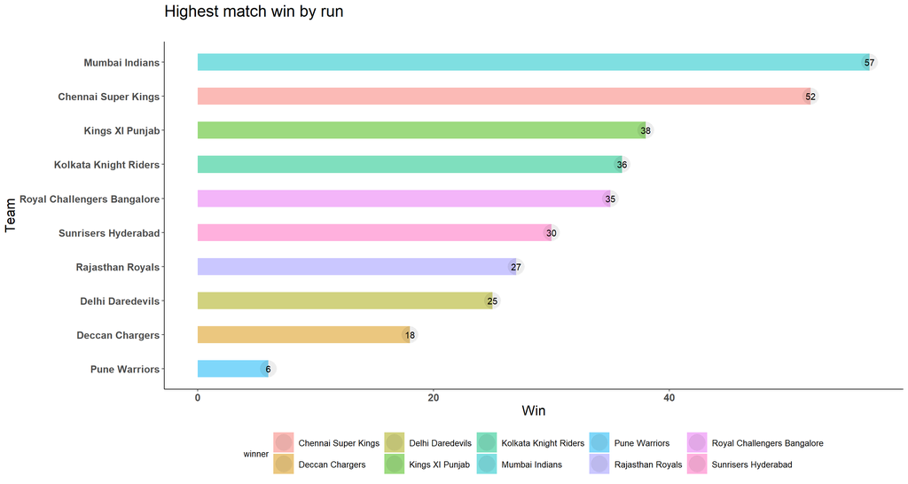

```r
ggplot(most_win_by_runs,aes(reorder(winner,Total_win),Total_win,fill=winner,label=Total_win))+
  geom_bar(stat = "identity", width = 0.5, alpha = 0.5)+
  geom_point(size=9, color="black",alpha=0.07)+
  scale_x_discrete(labels = most_win_by_runs[order(most_win_by_runs$Total_win),]$winner) +
  theme_classic()+
  geom_text(aes(winner,Total_win, label = Total_win))+
  labs(x = "Team", y = "Win", title = "Highest match win by run", subtitle = "")+
  coord_flip()+
  theme(axis.text = element_text(size = 12, face = "bold"),title  =  element_text(size = 16))+
  theme(legend.title = element_text(size=10),legend.text = element_text(size=10),legend.position="bottom")
```

**From the above plot, we can see that Mumbai Indians have won the most matches when batting first.**

#### **Teams winning by highest margin of runs**

```r
highest_win_margin = matches %>%
  select(winner,season,win_by_runs) %>%
  arrange(desc(win_by_runs)) %>%
  top_n(10) %>%
  ungroup() %>%
  mutate(Rank = as.factor(1:10))
datatable(highest_win_margin)
```

|  | winner | season | win_by_runs | Rank |
| --- | --- | --- | --- | --- |
| 1 | Mumbai Indians | 2017 | 146 | 1 |
| 2 | Royal Challengers Bangalore | 2016 | 144 | 2 |
| 3 | Kolkata Knight Riders | 2008 | 140 | 3 |
| 4 | Royal Challengers Bangalore | 2015 | 138 | 4 |
| 5 | Royal Challengers Bangalore | 2013 | 130 | 5 |
| 6 | Sunrisers Hyderabad | 2019 | 118 | 6 |
| 7 | Kings XI Punjab | 2011 | 111 | 7 |
| 8 | Rajasthan Royals | 2008 | 105 | 8 |
| 9 | Mumbai Indians | 2018 | 102 | 9 |
| 10 | Mumbai Indians | 2010 | 98 | 10 |

#### **Plot a corresponding bar graph**

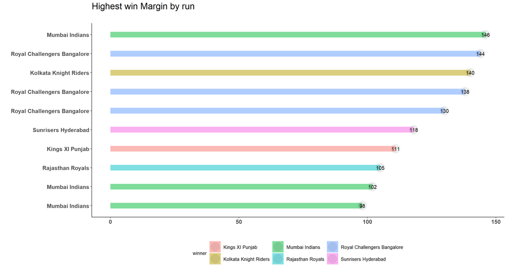

```r
ggplot(highest_win_margin)+
  aes(reorder(Rank, win_by_runs), win_by_runs,fill=winner,label=win_by_runs)+
  geom_bar(stat = "identity", width = 0.3, alpha = 0.5)+
  geom_point(size=9, color="black",alpha=0.07)+
  scale_x_discrete(labels = highest_win_margin[order(highest_win_margin$win_by_runs),]$winner) +
  theme_classic()+
  geom_text(aes(Rank, win_by_runs, label = win_by_runs))+
  labs(x = "", y = "", title = "Highest win Margin by run", subtitle = "")+
  coord_flip()+
  theme(axis.text = element_text(size = 12, face = "bold"), title  =  element_text(size = 16))+
  theme(legend.title = element_text(size=10),legend.text = element_text(size=10),legend.position="bottom")
```

**From the above plot, we can see that Mumbai Indians have won by the biggest margin.**

#### **Narrowest win margin (by 1 run)**

```r
win_by_one_runs=matches %>%
  select(team1,team2,venue,city,season,winner,win_by_runs)%>%
  filter(win_by_runs==1)%>%
  top_n(10)%>%
  arrange(season)
datatable(win_by_one_runs)
```

|  | team1 | team2 | venue | city | season | winner | win_by_runs |
| --- | --- | --- | --- | --- | --- | --- | --- |
| 1 | Kings XI Punjab | Mumbai Indians | Wankhede Stadium | Mumbai | 2008 | Kings XI Punjab | 1 |
| 2 | Kings XI Punjab | Deccan Chargers | New Wanderers Stadium | Johannesburg | 2009 | Kings XI Punjab | 1 |
| 3 | Delhi Daredevils | Rajasthan Royals | Feroz Shah Kotla | Delhi | 2012 | Delhi Daredevils | 1 |
| 4 | Mumbai Indians | Pune Warriors | Subrata Roy Sahara Stadium | Pune | 2012 | Mumbai Indians | 1 |
| 5 | Chennai Super Kings | Delhi Daredevils | MA Chidambaram Stadium, Chepauk | Chennai | 2015 | Chennai Super Kings | 1 |
| 6 | Gujarat Lions | Delhi Daredevils | Feroz Shah Kotla | Delhi | 2016 | Gujarat Lions | 1 |
| 7 | Royal Challengers Bangalore | Kings XI Punjab | Punjab Cricket Association IS Bindra Stadium, Mohali | Chandigarh | 2016 | Royal Challengers Bangalore | 1 |
| 8 | Mumbai Indians | Rising Pune Supergiant | Rajiv Gandhi International Stadium, Uppal | Hyderabad | 2017 | Mumbai Indians | 1 |
| 9 | Royal Challengers Bangalore | Chennai Super Kings | M. Chinnaswamy Stadium | Bengaluru | 2019 | Royal Challengers Bangalore | 1 |
| 10 | Mumbai Indians | Chennai Super Kings | Rajiv Gandhi Intl. Cricket Stadium | Hyderabad | 2019 | Mumbai Indians | 1 |

#### **In most matches, the team wins by bowling first**

```r
most_win_by_Wickets=matches %>%
  filter(win_by_wickets!=0)%>%
  group_by(winner) %>%
  dplyr::summarise(Total_win=n()) %>%
  arrange(desc(Total_win))%>%
  top_n(10)
datatable(most_win_by_Wickets)
```

|  | winner | Total_win |
| --- | --- | --- |
| 1 | Kolkata Knight Riders | 56 |
| 2 | Mumbai Indians | 50 |
| 3 | Chennai Super Kings | 48 |
| 4 | Royal Challengers Bangalore | 48 |
| 5 | Rajasthan Royals | 46 |
| 6 | Delhi Daredevils | 42 |
| 7 | Kings XI Punjab | 42 |
| 8 | Sunrisers Hyderabad | 27 |
| 9 | Gujarat Lions | 12 |
| 10 | Deccan Chargers | 11 |